# Neural Representations of Multilayer Social Network Information Analysis: Univariate Analyses

Ovidia Stanoi

4/12/2025

In this script, we ran 3 regression models. The first model (Model 1) estimates participants’ neural responses to peers’ faces in our 9 ROIs as a function of how much more status peers have relative to them in a **dual space that includes information from both the popularity and leadership dimension** (`dual_relative_status`). The second model (Model 2) estimates participants’ neural responses to peers’ faces in the 9 ROIs as a function of how much more **popularity status** peers have relative to them. In practice, we estimated participants’ mean neural response to each peer face as a function of that peer’s popularity status, while holding constant the perceiver’s own popularity status. By including the participants’ own status in the model, the parameter of the relationship between the target’s status and neural activity provides an estimate of participants’ mean response to the targets’ status relative to their own. The third model (Model 3) estimates participants’ neural responses to peers’ faces in the 9 ROIs as a function of how much more **leadership status** peers have relative to them. The same method was used as in Model 2. To account for multiple comparisons, all models are run in a multilevel framework with random slopes per ROI. We also included random intercepts for perceivers and targets, nested within groups. **No** control variables were included in these models.

Clear global environment.

```r
remove(list=ls())
```

Open packages.

```r
library("tidyverse")
library("corrplot")
library("reshape")
library("rstanarm")
library("bmlm")
library("flextable")
library("officer")
library("performance")
```

Set up ggplot theme.

```r
theme_set(theme_bw() +
            theme(plot.title = element_text(size=14, hjust = .5),
                  axis.text=element_text(size=12),
                  axis.title=element_text(size=13),
                  # plot.title = element_text(size=20, hjust = .5), # use this for .pdf version of figures instead of .html
                  # axis.text=element_text(size=20),  # use this for .pdf version of figures instead of .html
                  # axis.title=element_text(size=22), # use this for .pdf version of figures instead of .html
                  axis.line = element_line(colour = "gray"),
                  panel.border = element_rect(colour = "gray"),
                  panel.grid.minor = element_blank(),
                  axis.text.x = element_text(angle = 15, hjust = 1),
                  panel.background = element_rect(colour = "gray", linewidth = .8),
                  legend.position = "none"))
```

Set up the file directory.

```r
path <- ""
```

Read the dataset including each participant’s ROI-level neural responses to different faces and status information.

```r
d <- read.csv(sprintf("%s/Data/univariate_dataset.csv", path)) %>%
  select(groupID, pid, face, roi, neural_response, dual_relative_status_cw,
         face_like_strength_in_cw, face_leader_strength_in_cw,
         pid_like_strength_in_cw, pid_leader_strength_in_cw)
```

Check the format of the dataset.

```r
head(d)
```

|  | groupID | pid | face | roi | neural_response | dual_relative_status_cw | face_like_strength_in_cw | face_leader_strength_in_cw | pid_like_strength_in_cw | pid_leader_strength_in_cw |
| --- | --- | --- | --- | --- | --- | --- | --- | --- | --- | --- |
| 1 | g10p | muri369 | muri368 | ERC | 0.07067577 | 0.07010922 | 0.07465642 | 0.03132934 | -0.3495278 | -0.3592026 |
| 2 | g10p | muri369 | muri368 | l_HPC | 1.10138371 | 0.07010922 | 0.07465642 | 0.03132934 | -0.3495278 | -0.3592026 |
| 3 | g10p | muri369 | muri368 | r_HPC | -0.87328208 | 0.07010922 | 0.07465642 | 0.03132934 | -0.3495278 | -0.3592026 |
| 4 | g10p | muri369 | muri368 | l_TPJ | 6.42793539 | 0.07010922 | 0.07465642 | 0.03132934 | -0.3495278 | -0.3592026 |
| 5 | g10p | muri369 | muri368 | r_TPJ | 0.07152718 | 0.07010922 | 0.07465642 | 0.03132934 | -0.3495278 | -0.3592026 |
| 6 | g10p | muri369 | muri368 | vmPFC | -1.57933816 | 0.07010922 | 0.07465642 | 0.03132934 | -0.3495278 | -0.3592026 |

# 1 Model 1 (Relative Dual Status)

Run regression model for relative dual status.

```r
# options(mc.cores = parallel::detectCores())
# m <- stan_glmer(neural_response ~ dual_relative_status_cw +
#                   (1 | groupID:pid) + (1 | groupID:face) +
#                   (dual_relative_status_cw | roi),
#             data = d,  iter = 4000,
#             control = list(adapt_delta = 0.99),
#             seed = 123)
# save(m, file = sprintf("%s/Model Results/Univariate_Model_2D_Relative_Status_no_controls.RData", path))
```

Obtain ROI-level varying betas for the main effect of targets’ **relative dual status measures** on the perceivers’ ROI-level neural responses.

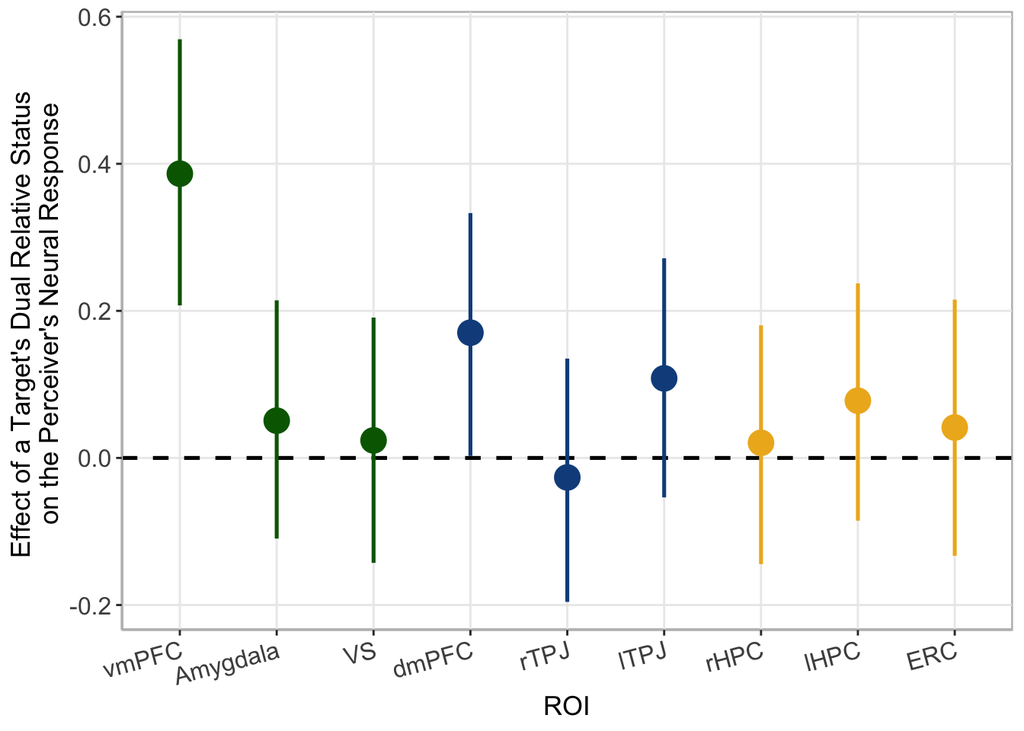

```r
# 0. Load model results
load(sprintf("%s/Model Results/Univariate_Model_2D_Relative_Status_no_controls.RData", path))

# 1.a. draws for overall mean
mu_b_sims <- as.matrix(m,
                       pars = "dual_relative_status_cw")
# 1.b. draws for roi-level error
b_sims <- as.matrix(m,
                    regex_pars = "b\\[dual_relative_status_cw roi:")

# 1.c. draws for roi-level varying slopes
b_sims <- as.numeric(mu_b_sims) + b_sims

# 2. Compute mean, SD, and 95% credible interval of varying slopes
# 2.a. Posterior mean and SD of each beta
b_mean <- apply(X = b_sims,     # posterior mean
                MARGIN = 2,
                FUN = mean)
b_sd <- apply(X = b_sims,       # posterior SD
              MARGIN = 2,
              FUN = sd)
# 2.b. Posterior 95% credible interval
b_quant <- apply(X = b_sims,
                 MARGIN = 2,
                 FUN = quantile,
                 probs = c(0.025, 0.975))

# 2.c. Create a CI data frame
b_quant <- data.frame(t(b_quant))
names(b_quant) <- c("beta_Q2.5", "beta_Q97.5")

# 3. Combine summary statistics of posterior simulation draws
b_df <- data.frame(b_mean, b_sd, b_quant)

# 4. Clean dataset
b_df$roi <- sub(".*:", "", rownames(b_df))
b_df$roi <- sub("]", "", b_df$roi)
b_df$beta_2d <- b_df$b_mean
b_df$sd <- b_df$b_sd
b_df$low_ci <- b_df$beta_Q2.5
b_df$upp_ci <- b_df$beta_Q97.5
rownames(b_df) <- NULL

# 5. Select only the columns we need: roi, beta, sd, low_ci, upp_ci
b_df <- subset(b_df, select = c(roi, beta_2d, sd, low_ci, upp_ci))

# 6. Rename ROIs and separate in 3 categories: valuation, soc cog, relational binding
b_df <- b_df %>%
  mutate(roi = dplyr::recode(roi,
                             "Saxe_dmPFC" = "dmPFC",
                             "HO_amygdala" = "Amygdala",
                             "r_HPC" = "rHPC",
                             "r_TPJ" = "rTPJ",
                             "Kable_VS" = "VS",
                             "ERC" = "ERC",
                             "l_HPC" = "lHPC",
                             "l_TPJ" = "lTPJ"),
         roi = factor(roi, levels = c("vmPFC", "Amygdala", "VS",
                                          "dmPFC", "rTPJ", "lTPJ",
                                          "rHPC", "lHPC", "ERC")),
         roi_type = ifelse(roi %in% c("vmPFC", "Amygdala", "VS"), "valuation",
                        ifelse(roi %in% c("dmPFC", "rTPJ", "lTPJ"), "social_cognition",
                               "relational_binding")))

# 7. Plot betas' posterior mean and 95% credible interval
ggplot(data = b_df,
       aes(x = roi,
           y = beta_2d)) +
  geom_hline(yintercept = 0,
             linewidth = 0.9, linetype = 2) +
  geom_pointrange(aes(ymin = low_ci,
                      ymax = upp_ci, color = roi_type),
                   size = 1.2, linewidth = .9) +
                   # size = 2, linewidth = 2.5) +
  scale_color_manual(values = c("goldenrod2", "dodgerblue4", "darkgreen")) +
  labs(x = "ROI", y = "Effect of a Target's Dual Relative Status
  on the Perceiver's Neural Response")
```

```r
# ggsave(sprintf("%s/Figures/univariate_multilevel_roi_beta_results_2D_relative_status_no_controls.pdf", path),
#          units="in", width=15, height=7, dpi=300)

# 8. Save beta results
write.csv(b_df, (sprintf("%s/Data/univariate_multilevel_roi_beta_results_2D_relative_status_no_controls.csv", path)),
          row.names = F)
```

Check results.

```r
# Arrange data
b_df_table <- b_df %>%
  mutate(across(where(is.numeric), ~ round(.x, 2)),
         CI_95 = paste0("[", round(low_ci, 2), ", ", round(upp_ci, 2), "]")) %>%
  select(-c(low_ci, upp_ci, roi_type)) %>%
  arrange(roi)

# Create table of results
b_df_table <- flextable(b_df_table) %>%
  set_header_labels(roi = "ROI",
    beta_2d = "Beta Estimate",
    sd = "SE",
    CI_95 = "95% CI") %>%
  autofit() %>%
  theme_booktabs()

# Save to Word document
doc <- read_docx() %>%
  body_add_par("Table: Univariate Results: Effect of Target's Relative Dual Status on ROI Neural Activity",
               style = "heading 2") %>%
  body_add_flextable(b_df_table)

print(doc, target = sprintf("%s/Tables/univariate_multilevel_roi_beta_results_2D_relative_status_no_controls.docx", path))

b_df_table
```

| ROI | Beta Estimate | SE | 95% CI |
| --- | --- | --- | --- |
| vmPFC | 0.39 | 0.09 | [0.21, 0.57] |
| Amygdala | 0.05 | 0.08 | [-0.11, 0.21] |
| VS | 0.02 | 0.08 | [-0.14, 0.19] |
| dmPFC | 0.17 | 0.08 | [0, 0.33] |
| rTPJ | -0.03 | 0.08 | [-0.2, 0.14] |
| lTPJ | 0.11 | 0.08 | [-0.05, 0.27] |
| rHPC | 0.02 | 0.08 | [-0.14, 0.18] |
| lHPC | 0.08 | 0.08 | [-0.09, 0.24] |
| ERC | 0.04 | 0.09 | [-0.13, 0.22] |

What percentage of the distribution is higher than zero for the vmPFC and dmPFC main effects?

```r
b_sims <- data.frame(b_sims)

# vmPFC
round((length(which(b_sims$b.dual_relative_status_cw.roi.vmPFC.>0))/8000)*100,1)
```

```
## [1] 100
```

```r
# dmPFC
round((length(which(b_sims$b.dual_relative_status_cw.roi.Saxe_dmPFC.>0))/8000)*100,1)
```

```
## [1] 97.8
```

Create a scatterplot that shows the relationship between targets’ relative dual status and perceivers’ neural responses in the **vmPFC**.

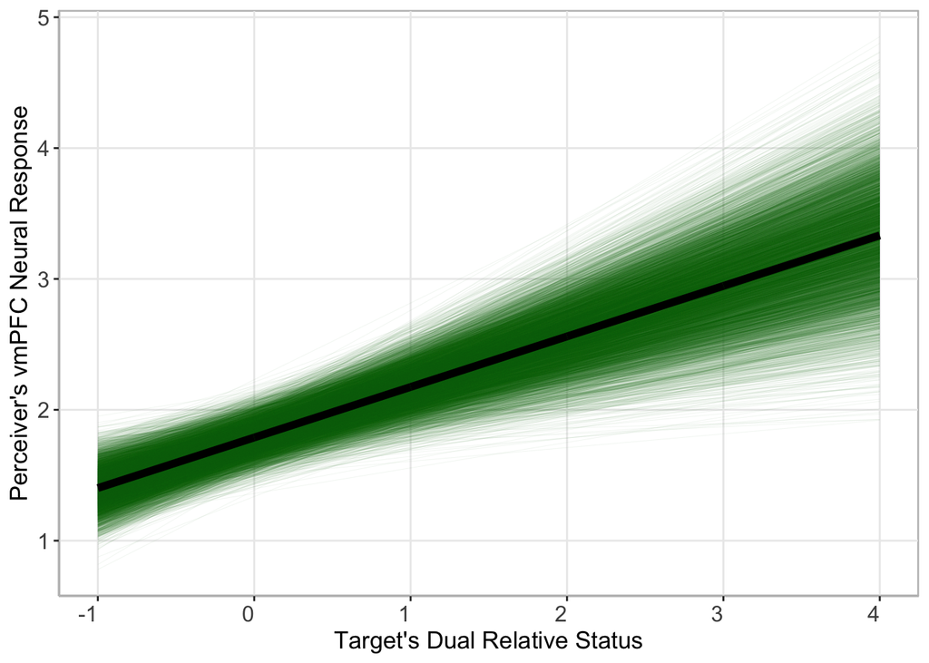

```r
# Extract posterior distributions -
# main and random effects for intercept & vmPFC
b_sims <- as.data.frame(m,
                       pars = c("(Intercept)", "b[(Intercept) roi:vmPFC]",
                                "dual_relative_status_cw",
                                "b[dual_relative_status_cw roi:vmPFC]"))

# Calculate the vmPFC-specific effects
b_sims$intercept <- b_sims$`(Intercept)` + b_sims$`b[(Intercept) roi:vmPFC]`
b_sims$b_dual_relative_status <- b_sims$dual_relative_status_cw + b_sims$`b[dual_relative_status_cw roi:vmPFC]`

# Extract all posterior distributions
p <- b_sims %>%
  select(intercept, b_dual_relative_status)

p <- p %>%
  dplyr::mutate(draw = 1:8000,
         m_int = median(intercept), # Extract fixed effects medians from the model
         m_b_dual_relative_status = median(b_dual_relative_status))  # Extract fixed effects median from the model

# Sample random draws
nr_random_draws <- 8000 # specify here number of random draws

# Create a dataframe that includes predicted y values for each random draw
p2 <- p[rep(seq_len(nrow(p)), each = 6), ] %>%
  mutate(seq = rep(-1:4, nr_random_draws)) %>%
  rowwise() %>%
  dplyr::mutate(y_draw = intercept + b_dual_relative_status * seq,
         y_fe = m_int + m_b_dual_relative_status * seq)

# Plot results
ggplot() +
  labs(y = "Perceiver's vmPFC Neural Response",
       x = "Target's Dual Relative Status") +
  geom_line(data = p2, aes(x = seq, y = y_draw, group = draw),
            color = "darkgreen", alpha = .1, size = .1) +
  geom_line(data = p2, aes(x = seq, y = y_fe), color = "black", size = 2) +
  theme(axis.text.x = element_text(angle = 0))
```

```r
# ggsave(file = sprintf("%s/Figures/univariate_vmpfc_2D_scatterplot_no_controls.pdf", path),
#        units="in", width=7, height=6, dpi=300)
```

Create a scatterplot that shows the relationship between targets’ relative dual status and perceivers’ neural responses in the **dmPFC**.

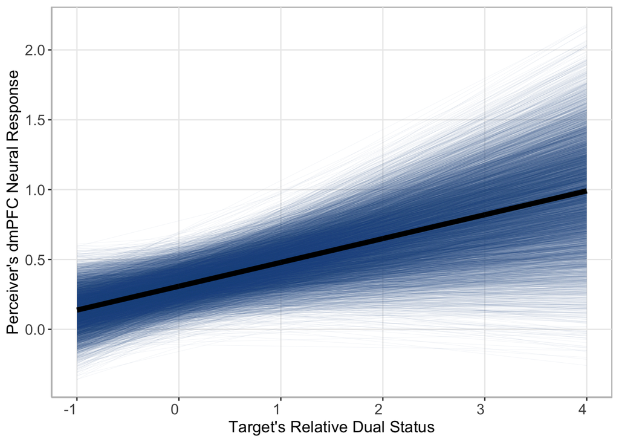

```r
# Extract posterior distributions -
# main and random effects for intercept & dmPFC
b_sims <- as.data.frame(m,
                       pars = c("(Intercept)", "b[(Intercept) roi:Saxe_dmPFC]",
                                "dual_relative_status_cw",
                                "b[dual_relative_status_cw roi:Saxe_dmPFC]"))

# Calculate the dmPFC-specific effects
b_sims$intercept <- b_sims$`(Intercept)` + b_sims$`b[(Intercept) roi:Saxe_dmPFC]`
b_sims$b_dual_relative_status <- b_sims$dual_relative_status_cw + b_sims$`b[dual_relative_status_cw roi:Saxe_dmPFC]`

# Extract all posterior distributions
p <- b_sims %>%
  select(intercept, b_dual_relative_status)

p <- p %>%
  dplyr::mutate(draw = 1:8000,
         m_int = median(intercept), # Extract fixed effects medians from the model
         m_b_dual_relative_status = median(b_dual_relative_status))  # Extract fixed effects median from the model

# Sample random draws
nr_random_draws <- 8000 # specify here number of random draws

# Create a dataframe that includes predicted y values for each random draw
p2 <- p[rep(seq_len(nrow(p)), each = 6), ] %>%
  mutate(seq = rep(-1:4, nr_random_draws)) %>%
  rowwise() %>%
  dplyr::mutate(y_draw = intercept + b_dual_relative_status * seq,
         y_fe = m_int + m_b_dual_relative_status * seq)

# Plot relationship
ggplot() +
  labs(y = "Perceiver's dmPFC Neural Response",
       x = "Target's Relative Dual Status") +
  geom_line(data = p2, aes(x = seq, y = y_draw, group = draw),
            color = "dodgerblue4", alpha = .1, size = .1) +
  geom_line(data = p2, aes(x = seq, y = y_fe), color = "black", size = 2) +
  theme(axis.text.x = element_text(angle = 0))
```

```r
# ggsave(file = sprintf("%s/Figures/univariate_dmpfc_2D_scatterplot_no_controls.pdf", path),
#         units="in", width=7, height=6, dpi=300)
```

# 2 Model 2 (Relative Popularity Status)

Run regression model for relative popularity status alone.

```r
# options(mc.cores = parallel::detectCores())
# m2 <- stan_glmer(neural_response ~ face_like_strength_in_cw * pid_like_strength_in_cw +
#                    (1 | groupID:pid) + (1 | groupID:face) +
#                    (face_like_strength_in_cw | roi),
#             data = d,  iter = 4000,
#             control = list(adapt_delta = 0.99),
#             seed = 123)
# save(m2, file = sprintf("%s/Model Results/Univariate_Model_Popularity_Relative_Status_no_controls.RData", path))
```

Obtain ROI-level varying betas for the main effect of a **target’s popularity status measure** on the perceiver’s ROI-level neural responses. Since we are controlling in the model for the perceiver’s popularity status, this is in effect a measure of the target’s **relative** popularity status.

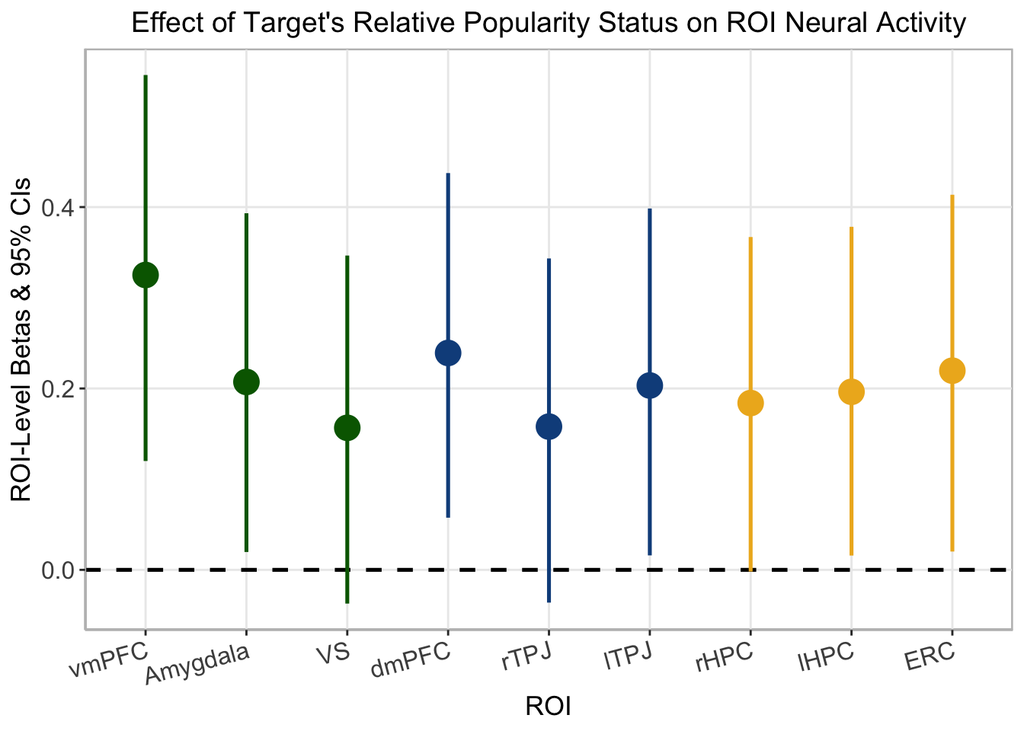

```r
# 0. Load model results
load(sprintf("%s/Model Results/Univariate_Model_Popularity_Relative_Status_no_controls.RData", path))

# 1.a. draws for overall mean
mu_b_sims <- as.matrix(m2,
                       pars = "face_like_strength_in_cw")
# 1.b. draws for roi-level error
b_sims <- as.matrix(m2,
                    regex_pars = "b\\[face_like_strength_in_cw roi:")

# 1.c. draws for roi-level varying slopes
b_sims <- as.numeric(mu_b_sims) + b_sims

# 2. Compute mean, SD, and 95% credible interval of varying slopes
# 2.a. Posterior mean and SD of each beta
b_mean <- apply(X = b_sims,     # posterior mean
                MARGIN = 2,
                FUN = mean)
b_sd <- apply(X = b_sims,       # posterior SD
              MARGIN = 2,
              FUN = sd)

# 2.b. Posterior 95% credible interval
b_quant <- apply(X = b_sims,
                 MARGIN = 2,
                 FUN = quantile,
                 probs = c(0.025, 0.975))

# 2.c. Create a CI data frame
b_quant <- data.frame(t(b_quant))
names(b_quant) <- c("beta_Q2.5", "beta_Q97.5")

# 3. Combine summary statistics of posterior simulation draws
b_df <- data.frame(b_mean, b_sd, b_quant)

# 4. Clean dataset
b_df$roi <- sub(".*:", "", rownames(b_df))
b_df$roi <- sub("]", "", b_df$roi)
b_df$beta_like <- b_df$b_mean
b_df$sd <- b_df$b_sd
b_df$low_ci <- b_df$beta_Q2.5
b_df$upp_ci <- b_df$beta_Q97.5
rownames(b_df) <- NULL

# 5. Select only the columns we need: roi, beta, sd, low_ci, upp_ci
b_df <- subset(b_df, select = c(roi, beta_like, sd, low_ci, upp_ci))

# 6. Rename ROIs and separate in 3 categories: valuation, soc cog, relational binding
b_df <- b_df %>%
  mutate(roi = dplyr::recode(roi,
                             "Saxe_dmPFC" = "dmPFC",
                             "HO_amygdala" = "Amygdala",
                             "r_HPC" = "rHPC",
                             "r_TPJ" = "rTPJ",
                             "Kable_VS" = "VS",
                             "ERC" = "ERC",
                             "l_HPC" = "lHPC",
                             "l_TPJ" = "lTPJ"),
         roi = factor(roi, levels = c("vmPFC", "Amygdala", "VS",
                                          "dmPFC", "rTPJ", "lTPJ",
                                          "rHPC", "lHPC", "ERC")),
         roi_type = ifelse(roi %in% c("vmPFC", "Amygdala", "VS"), "valuation",
                        ifelse(roi %in% c("dmPFC", "rTPJ", "lTPJ"), "social_cognition",
                               "relational_binding")))

# 7. Plot betas' posterior means and 95% credible intervals
ggplot(data = b_df,
       aes(x = roi,
           y = beta_like)) +
  geom_hline(yintercept = 0,
             linewidth = 0.9, linetype = 2) +
  geom_pointrange(aes(ymin = low_ci,
                      ymax = upp_ci, color = roi_type),
                  size = 1.2, linewidth = .9) +
  scale_color_manual(values = c("goldenrod2", "dodgerblue4", "darkgreen")) +
  labs(x = "ROI", y = "ROI-Level Betas & 95% CIs",
       title = "Effect of Target's Relative Popularity Status on ROI Neural Activity")
```

```r
# ggsave(sprintf("%s/Figures/univariate_multilevel_roi_beta_results_popularity_relative_status_no_controls.pdf", path),
#        units="in", width=12, height=7, dpi=300)

# 8. Save beta results
write.csv(b_df, (sprintf("%s/Data/univariate_multilevel_roi_beta_results_popularity_relative_status_no_controls.csv", path)),
          row.names = F)
```

Check results.

```r
# Arrange data
b_df_table <- b_df %>%
  mutate(across(where(is.numeric), ~ round(.x, 2)),
         CI_95 = paste0("[", round(low_ci, 2), ", ", round(upp_ci, 2), "]")) %>%
  select(-c(low_ci, upp_ci, roi_type)) %>%
  arrange(roi)

# Create table of results
b_df_table <- flextable(b_df_table) %>%
  set_header_labels(roi = "ROI",
    beta_like = "Beta Estimate",
    sd = "SE",
    CI_95 = "95% CI") %>%
  autofit() %>%
  theme_booktabs()

# Save to Word document
doc <- read_docx() %>%
  body_add_par("Table: Univariate Results: Effect of Target's Relative Popularity Status on ROI Neural Activity",
               style = "heading 2") %>%
  body_add_flextable(b_df_table)

print(doc, target = sprintf("%s/Tables/univariate_multilevel_roi_beta_results_popularity_relative_status_no_controls.docx", path))

b_df_table
```

| ROI | Beta Estimate | SE | 95% CI |
| --- | --- | --- | --- |
| vmPFC | 0.33 | 0.11 | [0.12, 0.55] |
| Amygdala | 0.21 | 0.09 | [0.02, 0.39] |
| VS | 0.16 | 0.10 | [-0.04, 0.35] |
| dmPFC | 0.24 | 0.10 | [0.06, 0.44] |
| rTPJ | 0.16 | 0.09 | [-0.04, 0.34] |
| lTPJ | 0.20 | 0.10 | [0.02, 0.4] |
| rHPC | 0.18 | 0.09 | [0, 0.37] |
| lHPC | 0.20 | 0.09 | [0.02, 0.38] |
| ERC | 0.22 | 0.10 | [0.02, 0.41] |

What percentage of the distribution is higher than zero for different ROI main effects?

```r
b_sims <- data.frame(b_sims)

# vmPFC
round((length(which(b_sims$b.face_like_strength_in_cw.roi.vmPFC.>0))/8000)*100,1)
```

```
## [1] 99.9
```

```r
# bilateral amygdala
round((length(which(b_sims$b.face_like_strength_in_cw.roi.HO_amygdala.>0))/8000)*100,1)
```

```
## [1] 98.4
```

```r
# dmPFC
round((length(which(b_sims$b.face_like_strength_in_cw.roi.Saxe_dmPFC.>0))/8000)*100,1)
```

```
## [1] 99.6
```

```r
# lTPJ
round((length(which(b_sims$b.face_like_strength_in_cw.roi.l_TPJ.>0))/8000)*100,1)
```

```
## [1] 98.4
```

```r
# lHPC
round((length(which(b_sims$b.face_like_strength_in_cw.roi.l_HPC.>0))/8000)*100,1)
```

```
## [1] 98.2
```

```r
# ERC
round((length(which(b_sims$b.face_like_strength_in_cw.roi.ERC.>0))/8000)*100,1)
```

```
## [1] 98.2
```

# 3 Model 3 (Relative Leadership Status)

Run regression model for relative leadership status alone.

```r
# options(mc.cores = parallel::detectCores())
# m3 <- stan_glmer(neural_response ~ face_leader_strength_in_cw * pid_leader_strength_in_cw +
#                    (1 | groupID:pid) + (1 | groupID:face) +
#                    (face_leader_strength_in_cw | roi),
#             data = d,  iter = 4000,
#             control = list(adapt_delta = 0.99),
#             seed = 123)
# save(m3, file = sprintf("%s/Model Results/Univariate_Model_Leadership_Relative_Status_no_controls.RData", path))
```

Obtain ROI-level varying betas for the main effect of a **target’s leadership status measure** on the perceiver’s ROI-level neural responses. Since we are controlling in the model for the perceiver’s leadership status, this is in effect a measure of the target’s **relative** leadership status.

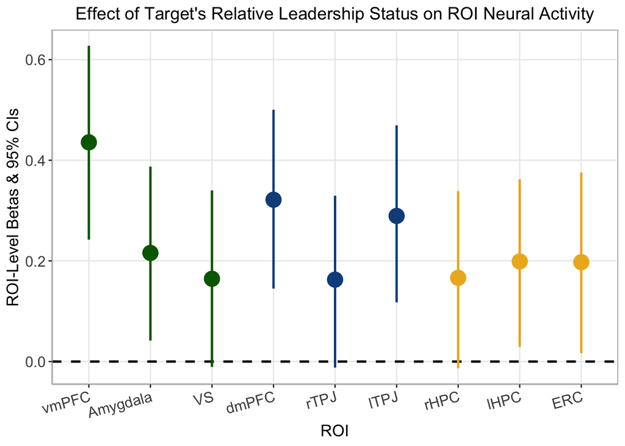

```r
# 0. Load model results
load(sprintf("%s/Model Results/Univariate_Model_Leadership_Relative_Status_no_controls.RData", path))

# 1.a. draws for overall mean
mu_b_sims <- as.matrix(m3,
                       pars = "face_leader_strength_in_cw")
# 1.b. draws for roi-level error
b_sims <- as.matrix(m3,
                    regex_pars = "b\\[face_leader_strength_in_cw roi:")

# 1.c. draws for roi-level varying slopes
b_sims <- as.numeric(mu_b_sims) + b_sims

# 2. Compute mean, SD, and 95% credible interval of varying slopes
# 2.a. Posterior mean and SD of each beta
b_mean <- apply(X = b_sims,     # posterior mean
                MARGIN = 2,
                FUN = mean)
b_sd <- apply(X = b_sims,       # posterior SD
              MARGIN = 2,
              FUN = sd)
# 2.b. Posterior 95% credible interval
b_quant <- apply(X = b_sims,
                 MARGIN = 2,
                 FUN = quantile,
                 probs = c(0.025, 0.975))

# 2.c. Create a CI data frame
b_quant <- data.frame(t(b_quant))
names(b_quant) <- c("beta_Q2.5", "beta_Q97.5")

# 3. Combine summary statistics of posterior simulation draws
b_df <- data.frame(b_mean, b_sd, b_quant)

# 4. Clean dataset
b_df$roi <- sub(".*:", "", rownames(b_df))
b_df$roi <- sub("]", "", b_df$roi)
b_df$beta_leader <- b_df$b_mean
b_df$sd <- b_df$b_sd
b_df$low_ci <- b_df$beta_Q2.5
b_df$upp_ci <- b_df$beta_Q97.5
rownames(b_df) <- NULL

# 5. Select only the columns we need: roi, beta, sd, low_ci, upp_ci
b_df <- subset(b_df, select = c(roi, beta_leader, sd, low_ci, upp_ci))

# 6. Rename ROIs and separate in 3 categories: valuation, soc cog, relational binding
b_df <- b_df %>%
  mutate(roi = dplyr::recode(roi,
                             "Saxe_dmPFC" = "dmPFC",
                             "HO_amygdala" = "Amygdala",
                             "r_HPC" = "rHPC",
                             "r_TPJ" = "rTPJ",
                             "Kable_VS" = "VS",
                             "ERC" = "ERC",
                             "l_HPC" = "lHPC",
                             "l_TPJ" = "lTPJ"),
         roi = factor(roi, levels = c("vmPFC", "Amygdala", "VS",
                                          "dmPFC", "rTPJ", "lTPJ",
                                          "rHPC", "lHPC", "ERC")),
         roi_type = ifelse(roi %in% c("vmPFC", "Amygdala", "VS"), "valuation",
                        ifelse(roi %in% c("dmPFC", "rTPJ", "lTPJ"), "social_cognition",
                               "relational_binding")))

# 7. Plot betas' posterior means and 95% credible intervals
ggplot(data = b_df,
       aes(x = roi,
           y = beta_leader)) +
  geom_hline(yintercept = 0,
             linewidth = 0.9, linetype = 2) +
  geom_pointrange(aes(ymin = low_ci,
                      ymax = upp_ci, color = roi_type),
                  size = 1.2, linewidth = .9) +
  scale_color_manual(values = c("goldenrod2", "dodgerblue4", "darkgreen")) +
  labs(x = "ROI", y = "ROI-Level Betas & 95% CIs",
       title = "Effect of Target's Relative Leadership Status on ROI Neural Activity")
```

```r
# ggsave(sprintf("%s/Figures/univariate_multilevel_roi_beta_results_leadership_relative_status_no_controls.pdf", path),
#        units="in", width=12, height=7, dpi=300)

# 8. Save beta results
write.csv(b_df, (sprintf("%s/Data/univariate_multilevel_roi_beta_results_leadership_relative_status_no_controls.csv", path)),
          row.names = F)
```

Check results.

```r
# Arrange data
b_df_table <- b_df %>%
  mutate(across(where(is.numeric), ~ round(.x, 2)),
         CI_95 = paste0("[", round(low_ci, 2), ", ", round(upp_ci, 2), "]")) %>%
  select(-c(low_ci, upp_ci, roi_type)) %>%
  arrange(roi)

# Create table of results
b_df_table <- flextable(b_df_table) %>%
  set_header_labels(roi = "ROI",
    beta_leader = "Beta Estimate",
    sd = "SE",
    CI_95 = "95% CI") %>%
  autofit() %>%
  theme_booktabs()

# Save to Word document
doc <- read_docx() %>%
  body_add_par("Table: Univariate Results: Effect of Target's Leadership Popularity Status on ROI Neural Activity",
               style = "heading 2") %>%
  body_add_flextable(b_df_table)

print(doc, target = sprintf("%s/Tables/univariate_multilevel_roi_beta_results_leadership_relative_status_no_controls.docx", path))

b_df_table
```

| ROI | Beta Estimate | SE | 95% CI |
| --- | --- | --- | --- |
| vmPFC | 0.44 | 0.10 | [0.24, 0.63] |
| Amygdala | 0.22 | 0.09 | [0.04, 0.39] |
| VS | 0.16 | 0.09 | [-0.01, 0.34] |
| dmPFC | 0.32 | 0.09 | [0.14, 0.5] |
| rTPJ | 0.16 | 0.09 | [-0.01, 0.33] |
| lTPJ | 0.29 | 0.09 | [0.12, 0.47] |
| rHPC | 0.17 | 0.09 | [-0.01, 0.34] |
| lHPC | 0.20 | 0.09 | [0.03, 0.36] |
| ERC | 0.20 | 0.09 | [0.02, 0.38] |

What percentage of the posterior distribution is higher than zero for different ROIs?

```r
b_sims <- data.frame(b_sims)

# vmPFC
round((length(which(b_sims$b.face_leader_strength_in_cw.roi.vmPFC.>0))/8000)*100,1)
```

```
## [1] 100
```

```r
# bilateral amygdala
round((length(which(b_sims$b.face_leader_strength_in_cw.roi.HO_amygdala.>0))/8000)*100,1)
```

```
## [1] 99.2
```

```r
# dmPFC
round((length(which(b_sims$b.face_leader_strength_in_cw.roi.Saxe_dmPFC.>0))/8000)*100,1)
```

```
## [1] 100
```

```r
# lTPJ
round((length(which(b_sims$b.face_leader_strength_in_cw.roi.l_TPJ.>0))/8000)*100,1)
```

```
## [1] 100
```

```r
# lHPC
round((length(which(b_sims$b.face_leader_strength_in_cw.roi.l_HPC.>0))/8000)*100,1)
```

```
## [1] 98.9
```

```r
# ERC
round((length(which(b_sims$b.face_leader_strength_in_cw.roi.ERC.>0))/8000)*100,1)
```

```
## [1] 98.4
```